# Python Project - Dataset Exploration on Prosper loan

## by Olayinka Ahmed Ibitowa

## Introduction

> This project is part of my Phython Data Analyst degree program. I investigated an Exploratory Data Analysis (EDA) on a data set from Prosper loan, which is the first America lending platform with over 9 billion dollars in funded loans.

> the Data set contains 113,937 rows and 81 columns. Some of the columns are the loan amount, terms, BorrowersRate, employment status etc.

> The main purpose of this project is to analyse the data set and summarised my findings for future cusotmer users and also to determine what influences Prosper loan interest rate.

## Preliminary Wrangling

```python
# import all packages and set plots to be embedded inline
import pandas as pd
import numpy as np
import seaborn as sns
import datetime
import matplotlib.pyplot as plt
from wordcloud import WordCloud, STOPWORDS, ImageColorGenerator
from PIL import Image
%matplotlib inline

# sizing my plot
plt.rcParams["axes.grid"] = False
# sns.set(rc={'figure.figsize':(12,8)})
```

```python
#loading the dataset
df = pd.read_csv('Prosper Loan.csv')
```

```python
#printin the first 5 rows
df.head()
```

|  | ListingKey | ListingNumber | ListingCreationDate | CreditGrade | Term | LoanStatus | ClosedDate | BorrowerAPR | BorrowerRate | LenderYield | ... | LP_ServiceFees | LP_CollectionFees | LP_GrossPrincipalLoss | LP_NetPrincipalLoss | LP_NonPrincipalRecoverypayments | PercentFunded | Recommendations | InvestmentFromFriendsCount | InvestmentFromFriendsAmount | Investors |
| --- | --- | --- | --- | --- | --- | --- | --- | --- | --- | --- | --- | --- | --- | --- | --- | --- | --- | --- | --- | --- | --- |
| 0 | 1021339766868145413AB3B | 193129 | 09:29.3 | C | 36 | Completed | 14/08/2009 00:00 | 0.16516 | 0.1580 | 0.1380 | ... | -133.18 | 0.0 | 0.0 | 0.0 | 0.0 | 1.0 | 0 | 0 | 0.0 | 258 |
| 1 | 10273602499503308B223C1 | 1209647 | 28:07.9 | NaN | 36 | Current | NaN | 0.12016 | 0.0920 | 0.0820 | ... | 0.00 | 0.0 | 0.0 | 0.0 | 0.0 | 1.0 | 0 | 0 | 0.0 | 1 |
| 2 | 0EE9337825851032864889A | 81716 | 00:47.1 | HR | 36 | Completed | 17/12/2009 00:00 | 0.28269 | 0.2750 | 0.2400 | ... | -24.20 | 0.0 | 0.0 | 0.0 | 0.0 | 1.0 | 0 | 0 | 0.0 | 41 |
| 3 | 0EF5356002482715299901A | 658116 | 02:35.0 | NaN | 36 | Current | NaN | 0.12528 | 0.0974 | 0.0874 | ... | -108.01 | 0.0 | 0.0 | 0.0 | 0.0 | 1.0 | 0 | 0 | 0.0 | 158 |
| 4 | 0F023589499656230C5E3E2 | 909464 | 38:39.1 | NaN | 36 | Current | NaN | 0.24614 | 0.2085 | 0.1985 | ... | -60.27 | 0.0 | 0.0 | 0.0 | 0.0 | 1.0 | 0 | 0 | 0.0 | 20 |

5 rows × 81 columns

```python
#number of rows and columns
df.shape
```

```
(113937, 81)
```

```python
#summary of dataset
df.info()
```

```
<class 'pandas.core.frame.DataFrame'>
RangeIndex: 113937 entries, 0 to 113936
Data columns (total 81 columns):
 #   Column                               Non-Null Count   Dtype
---  ------                               --------------   -----
 0   ListingKey                           113937 non-null  object
 1   ListingNumber                        113937 non-null  int64
 2   ListingCreationDate                  113937 non-null  object
 3   CreditGrade                          28953 non-null   object
 4   Term                                 113937 non-null  int64
 5   LoanStatus                           113937 non-null  object
 6   ClosedDate                           55089 non-null   object
 7   BorrowerAPR                          113912 non-null  float64
 8   BorrowerRate                         113937 non-null  float64
 9   LenderYield                          113937 non-null  float64
```

[output cut: 73 more lines]

### Cleaning of Dataset

> columns that are of importance are selected and assigned to a new dataframe.

```python
# the columns of interest related to customer are arrange in a new dataframe
interest = ['ListingNumber','ListingCreationDate','ProsperRating (Alpha)','ProsperScore',\
            'ListingCategory (numeric)', 'Occupation','EmploymentStatus', \
            'IsBorrowerHomeowner', 'CurrentCreditLines', 'OpenRevolvingAccounts', 'DebtToIncomeRatio', \
            'IncomeVerifiable', 'LoanOriginalAmount', 'LoanStatus', \
            'CreditScoreRangeLower', 'CreditScoreRangeUpper','BorrowerState', \
            'LoanOriginationDate', 'IncomeRange','BorrowerAPR','BorrowerRate','StatedMonthlyIncome','Term', 'MonthlyLoanPayment']
```

```python
# assigning the column of interest to a dataframe
df_interest = df[interest]

#listing the first five column
df_interest.head()
```

|  | ListingNumber | ListingCreationDate | ProsperRating (Alpha) | ProsperScore | ListingCategory (numeric) | Occupation | EmploymentStatus | IsBorrowerHomeowner | CurrentCreditLines | OpenRevolvingAccounts | ... | CreditScoreRangeLower | CreditScoreRangeUpper | BorrowerState | LoanOriginationDate | IncomeRange | BorrowerAPR | BorrowerRate | StatedMonthlyIncome | Term | MonthlyLoanPayment |
| --- | --- | --- | --- | --- | --- | --- | --- | --- | --- | --- | --- | --- | --- | --- | --- | --- | --- | --- | --- | --- | --- |
| 0 | 193129 | 09:29.3 | NaN | NaN | 0 | Other | Self-employed | True | 5.0 | 1 | ... | 640.0 | 659.0 | CO | 12/09/2007 00:00 | $25,000-49,999 | 0.16516 | 0.1580 | 3083.333333 | 36 | 330.43 |
| 1 | 1209647 | 28:07.9 | A | 7.0 | 2 | Professional | Employed | False | 14.0 | 13 | ... | 680.0 | 699.0 | CO | 03/03/2014 00:00 | $50,000-74,999 | 0.12016 | 0.0920 | 6125.000000 | 36 | 318.93 |
| 2 | 81716 | 00:47.1 | NaN | NaN | 0 | Other | Not available | False | NaN | 0 | ... | 480.0 | 499.0 | GA | 17/01/2007 00:00 | Not displayed | 0.28269 | 0.2750 | 2083.333333 | 36 | 123.32 |
| 3 | 658116 | 02:35.0 | A | 9.0 | 16 | Skilled Labor | Employed | True | 5.0 | 7 | ... | 800.0 | 819.0 | GA | 01/11/2012 00:00 | $25,000-49,999 | 0.12528 | 0.0974 | 2875.000000 | 36 | 321.45 |
| 4 | 909464 | 38:39.1 | D | 4.0 | 2 | Executive | Employed | True | 19.0 | 6 | ... | 680.0 | 699.0 | MN | 20/09/2013 00:00 | $100,000+ | 0.24614 | 0.2085 | 9583.333333 | 36 | 563.97 |

5 rows × 24 columns

```python
#summary of df_interest
df_interest.info()
```

```
<class 'pandas.core.frame.DataFrame'>
RangeIndex: 113937 entries, 0 to 113936
Data columns (total 24 columns):
 #   Column                     Non-Null Count   Dtype
---  ------                     --------------   -----
 0   ListingNumber              113937 non-null  int64
 1   ListingCreationDate        113937 non-null  object
 2   ProsperRating (Alpha)      84853 non-null   object
 3   ProsperScore               84853 non-null   float64
 4   ListingCategory (numeric)  113937 non-null  int64
 5   Occupation                 110349 non-null  object
 6   EmploymentStatus           111682 non-null  object
 7   IsBorrowerHomeowner        113937 non-null  bool
 8   CurrentCreditLines         106333 non-null  float64
 9   OpenRevolvingAccounts      113937 non-null  int64
```

[output cut: 16 more lines]

```python
#summing the total null values in each columns
df_interest.isnull().sum()
```

[output not shown]

```python
#checking duplicates value
sum(df_interest.duplicated())
```

```
0
```

```python
#filtering my dataframe (df_interest) with non null rows in the ProsperRating column and assigning it to df_interest
df_interest[df_interest['ProsperRating (Alpha)'].notnull()]
df_interest = df_interest[df_interest['ProsperRating (Alpha)'].notnull()]
```

```python
df_interest.isnull().sum()
```

[output not shown]

```python
# refilling the null values with their mean for DebtToIncomeRatio and for occupation with unkonown
df_interest['Occupation'] = df_interest['Occupation'].fillna('Unknown')
df_interest['DebtToIncomeRatio'] = df_interest['DebtToIncomeRatio'].fillna(df_interest['DebtToIncomeRatio'].mean())
```

```python
df_interest.isnull().sum()
```

[output not shown]

```python
# checking the number of uniques in the columns of the dataset
df_interest.nunique()
```

[output not shown]

```python
df_interest.LoanStatus.unique()
```

```
array(['Current', 'Past Due (1-15 days)', 'Defaulted', 'Completed',
       'Chargedoff', 'Past Due (16-30 days)', 'Past Due (61-90 days)',
       'Past Due (31-60 days)', 'Past Due (91-120 days)',
       'FinalPaymentInProgress', 'Past Due (>120 days)'], dtype=object)
```

```python
# convert the Dtype of ListCreationDate to datetime
df_interest['ListingCreationDate'] = pd.to_datetime(df_interest['ListingCreationDate'], errors='coerce')

# extracting all date, month and year from the column of the ListCreationDate
#df_interest['date'] = df_interest['ListingCreationDate'].dt.date
#df_interest['month'] = df_interest['ListingCreationDate'].dt.month
#df_interest['year'] = df_interest['ListingCreationDate'].dt.year
```

```python
df_interest.info()
```

```
<class 'pandas.core.frame.DataFrame'>
Int64Index: 84853 entries, 1 to 113936
Data columns (total 23 columns):
 #   Column                     Non-Null Count  Dtype
---  ------                     --------------  -----
 0   ListingNumber              84853 non-null  int64
 1   ListingCreationDate        33825 non-null  datetime64[ns]
 2   ProsperRating (Alpha)      84853 non-null  object
 3   ProsperScore               84853 non-null  float64
 4   ListingCategory (numeric)  84853 non-null  int64
 5   Occupation                 84853 non-null  object
 6   EmploymentStatus           84853 non-null  object
 7   IsBorrowerHomeowner        84853 non-null  bool
 8   CurrentCreditLines         84853 non-null  float64
 9   OpenRevolvingAccounts      84853 non-null  int64
 10  DebtToIncomeRatio          84853 non-null  float64
 11  IncomeVerifiable           84853 non-null  bool
 12  LoanOriginalAmount         84853 non-null  int64
 13  LoanStatus                 84853 non-null  object
 14  CreditScoreRangeLower      84853 non-null  float64
 15  CreditScoreRangeUpper      84853 non-null  float64
 16  BorrowerState              84853 non-null  object
 17  LoanOriginationDate        84853 non-null  object
 18  IncomeRange                84853 non-null  object
 19  BorrowerAPR                84853 non-null  float64
 20  BorrowerRate               84853 non-null  float64
 21  StatedMonthlyIncome        84853 non-null  float64
 22  Term                       84853 non-null  int64
dtypes: bool(2), datetime64[ns](1), float64(8), int64(5), object(7)
memory usage: 14.4+ MB
```

```python
# converting datatype of selected columns
df_interest['ListingNumber']=df_interest['ListingNumber'].astype(str)
df_interest['ProsperScore']=df_interest['ProsperScore'].astype(int)
```

```python
df_interest['ListingCategory (numeric)'].unique()
```

```
array([ 2, 16,  1,  7, 13,  6, 15, 20, 19, 18,  3,  8, 11, 14,  9, 17, 10,
        0,  5, 12], dtype=int64)
```

```python
# Redefining the listing category to strings
list_categories = {0 : 'Not Available', 1 : 'Debt Consolidation', 2 : 'Home Improvement', 3: 'Business',
             4 : 'Personal Loan', 5 : 'Student Use', 6 : 'Auto', 7 : 'Other', 8 : 'Baby&Adoption',
             9 : 'Boat', 10 : 'Cosmetic Procedure', 11 : 'Engagement Ring', 12 : 'Green Loans',
             13 : 'Household Expenses', 14 : 'Large Purchases', 15 : 'Medical/Dental', 16 : 'Motorcycle',
             17 : 'RV', 18 : 'Taxes', 19 : 'Vacation', 20 : 'Wedding Loans'}

df_interest['ListingCategory'] = df_interest['ListingCategory (numeric)'].map(list_categories)

# droping the catefory Numeric
df_interest.drop(['ListingCategory (numeric)'], axis=1, inplace=True)
```

```python
# finding averge Credit Score Range
df_interest['CreditScore_average'] = (df_interest['CreditScoreRangeLower'] + df_interest['CreditScoreRangeUpper'])/2
```

```python
df_interest.info()
```

```
<class 'pandas.core.frame.DataFrame'>
Int64Index: 84853 entries, 1 to 113936
Data columns (total 24 columns):
 #   Column                 Non-Null Count  Dtype
---  ------                 --------------  -----
 0   ListingNumber          84853 non-null  object
 1   ListingCreationDate    33825 non-null  datetime64[ns]
 2   ProsperRating (Alpha)  84853 non-null  object
 3   ProsperScore           84853 non-null  int32
 4   Occupation             84853 non-null  object
 5   EmploymentStatus       84853 non-null  object
 6   IsBorrowerHomeowner    84853 non-null  bool
 7   CurrentCreditLines     84853 non-null  float64
 8   OpenRevolvingAccounts  84853 non-null  int64
 9   DebtToIncomeRatio      84853 non-null  float64
```

[output cut: 16 more lines]

```python
# Printing descriptive statistics for the column with selected numeric values
df_interest[['CurrentCreditLines', 'OpenRevolvingAccounts',
               'DebtToIncomeRatio', 'LoanOriginalAmount', 'StatedMonthlyIncome', 'BorrowerAPR','BorrowerRate']].describe()
```

|  | CurrentCreditLines | OpenRevolvingAccounts | DebtToIncomeRatio | LoanOriginalAmount | StatedMonthlyIncome | BorrowerAPR | BorrowerRate |
| --- | --- | --- | --- | --- | --- | --- | --- |
| count | 84853.000000 | 84853.000000 | 84853.000000 | 84853.000000 | 8.485300e+04 | 84853.000000 | 84853.000000 |
| mean | 10.508032 | 7.386292 | 0.258752 | 9083.440515 | 5.931175e+03 | 0.226658 | 0.196022 |
| std | 5.317401 | 4.515977 | 0.304333 | 6287.860058 | 8.239944e+03 | 0.079916 | 0.074631 |
| min | 0.000000 | 0.000000 | 0.000000 | 1000.000000 | 0.000000e+00 | 0.045830 | 0.040000 |
| 25% | 7.000000 | 4.000000 | 0.160000 | 4000.000000 | 3.434000e+03 | 0.163280 | 0.135900 |
| 50% | 10.000000 | 7.000000 | 0.240000 | 7500.000000 | 5.000000e+03 | 0.219450 | 0.187500 |
| 75% | 13.000000 | 10.000000 | 0.310000 | 13500.000000 | 7.083333e+03 | 0.292540 | 0.257400 |
| max | 59.000000 | 50.000000 | 10.010000 | 35000.000000 | 1.750003e+06 | 0.423950 | 0.360000 |

```python
df_interest.shape
```

```
(84853, 24)
```

### What is the structure of your dataset?

> The original dataset contains (113937, 81) column. After cleaning and selection of columns of importance, the dataframe now contains (84853, 24) column by rows. The dataframe contains columns such as ProsperScore, DebtToIncomeRatio, LoanOriginalAmount BorrowerAPR, BorrowerRate, Term etc. Most variables are numeric and categorical in nature.

### What is/are the main feature(s) of interest in your dataset?

> I am interested in finding:
> - What are the main factors affecting the interest rate? What's the average interest rate on big loans?
> - the interest rate applied for small loans? the size of loans do borrowers usually take out from Prosper? Who takes big loans? Who takes small loans?
> - Are there any differences between loans depending on different level of employment status?
> - Which category of listing takes the most loans and for what purpose?

## Univariate Exploration

[figure not shown]

```python
order_loanstatus=df_interest['LoanStatus'].value_counts().index
ax=sns.countplot(x='LoanStatus', data=df_interest, order=order_loanstatus, color='purple')
ax.bar_label(ax.containers[0], fmt='%.lf')
plt.xlabel('Loan Status')
plt.ylabel('Count')
plt.title('Loan Status Distribution')
plt.xticks(rotation=90)
plt.show();
```

```python
df_interest['LoanStatus'] = df_interest['LoanStatus'].apply(lambda x: x if 'Past Due' not in x else 'Past Due')
```

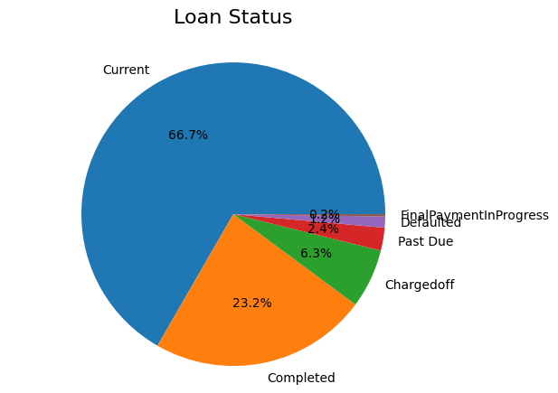

```python
loanstatus_counts = df_interest['LoanStatus'].value_counts()
plt.pie(loanstatus_counts, labels=loanstatus_counts.index, autopct='%1.1f%%')
plt.title('Loan Status', y=1.05, fontsize=16)
plt.axis('equal')
plt.show()
```

#### Notes

> Plotting in bars for better view and visuals as pie are overlapping due to the smaller percentages

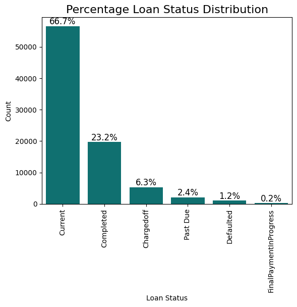

```python
# loanstatus_counts = df_interest['LoanStatus'].value_counts() already defined
# since pie chart is not exploding the smaller percentage, I had to use a bar for better viusals

# Calculate percentages
percentages = loanstatus_counts / loanstatus_counts.sum() * 100

# Plot the bar chart
ax = sns.barplot(x=loanstatus_counts.index, y=loanstatus_counts, color='teal')

# Display percentages above the bars
for i, val in enumerate(loanstatus_counts):
    ax.text(i, val, f'{percentages[i]:.1f}%', ha='center', va='bottom', fontsize=12)

plt.title('Percentage Loan Status Distribution', fontsize=16)
plt.xlabel('Loan Status')
plt.ylabel('Count')
plt.xticks(rotation=90)

plt.show()
```

#### Results explanation

> The distribution of the loan status shows about 66.7 percent are currenlty on the loan plan with about 23,2 percent completed. Past Due and defaulted are quite low which indicates the commitment of customers from Prsoper loan.

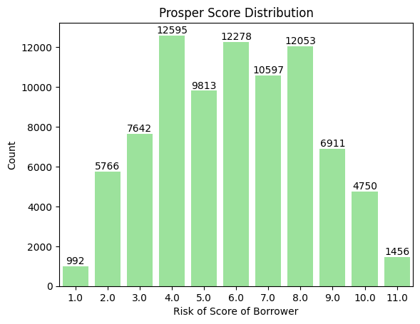

```python
ax=sns.countplot(x='ProsperScore', data=df_interest, color='lightgreen')
ax.bar_label(ax.containers[0], fmt='%.lf')
plt.xlabel('Risk of Score of Borrower')
plt.ylabel('Count')
plt.title('Prosper Score Distribution')
plt.show()
```

#### Results explanation

> PrsperScore ranges from 1 to 11 with 11 being the lowest risk and 1 the highest. The results shows that Prosper score has a bell shaped distribution spiking on score with 4, 6 and 8. Fewer customers are within the higest risk of score (1 to 3) and also within the lowest risk of score (9 to 119 while majority of the customer are between 4 and 8.

```python
df_interest.info()
```

```
<class 'pandas.core.frame.DataFrame'>
Int64Index: 84853 entries, 1 to 113936
Data columns (total 24 columns):
 #   Column                 Non-Null Count  Dtype
---  ------                 --------------  -----
 0   ListingNumber          84853 non-null  object
 1   ListingCreationDate    33825 non-null  datetime64[ns]
 2   ProsperRating (Alpha)  84853 non-null  object
 3   ProsperScore           84853 non-null  int32
 4   Occupation             84853 non-null  object
 5   EmploymentStatus       84853 non-null  object
 6   IsBorrowerHomeowner    84853 non-null  bool
 7   CurrentCreditLines     84853 non-null  float64
 8   OpenRevolvingAccounts  84853 non-null  int64
 9   DebtToIncomeRatio      84853 non-null  float64
```

[output cut: 16 more lines]

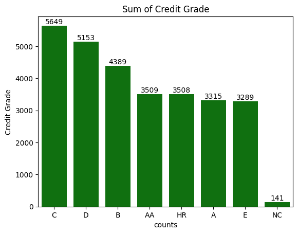

```python
order_creditgrade=df.CreditGrade.value_counts().index #creating an order in desc
ax=sns.countplot(x='CreditGrade', data=df, color='green', order=order_creditgrade)
ax.bar_label(ax.containers[0], fmt='%.lf') #showing value plot of each bar
plt.ylabel('Credit Grade')
plt.xlabel('counts')
plt.title('Sum of Credit Grade');
```

#### Results explanation

> The credit grade distribution is showed in descending order with over 5649 personnel being in the C grade and NC being the lowest of all.

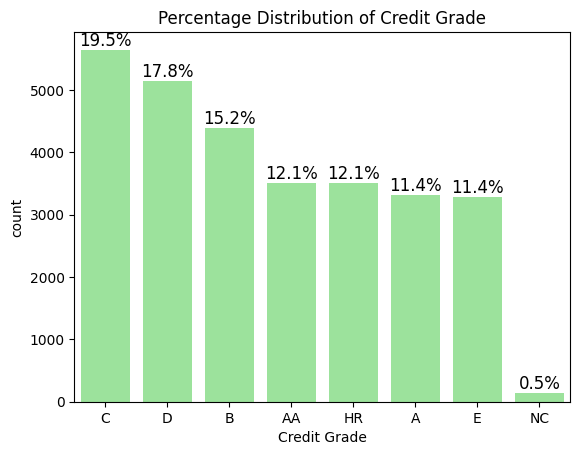

```python
order_creditgrade = df['CreditGrade'].value_counts().index  # Create an order in descending order

ax = sns.countplot(x='CreditGrade', data=df, color='lightgreen', order=order_creditgrade)

# Calculate the percentage values
total_count = len(df)
percentages = df['CreditGrade'].value_counts(normalize=True) * 100

# Display the percentage values on each bar
for i, val in enumerate(df['CreditGrade'].value_counts()):
    ax.text(i, val, f'{percentages[i]:.1f}%', ha='center', va='bottom', fontsize=12)

plt.ylabel('count')
plt.xlabel('Credit Grade')
plt.title('Percentage Distribution of Credit Grade')

plt.show()
```

#### Results explanation

> For better comparison, their percentage distribution was analyzed. Credit grade of C being the highest has about 19.5 percent while NC has about 0.5 percent. Other types of credit grade such as AA, A and B are also in a better position. This results explains that customers of Prsoper loan have a better credit grade

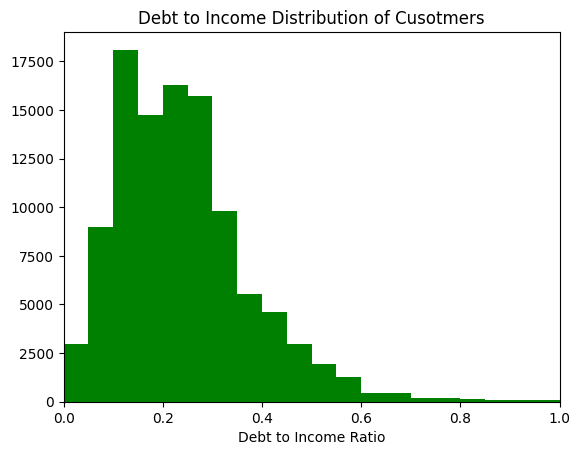

```python
binsize = 0.05
bins = np.arange(0, df_interest['DebtToIncomeRatio'].max()+binsize, binsize)
plt.hist(data = df_interest, x = 'DebtToIncomeRatio', bins=bins, color='green')
plt.xlabel('Debt to Income Ratio')
plt.xlim(0,1)
plt.title('Debt to Income Distribution of Cusotmers');
```

#### Results explanation

> The results indicates that most borrowers who applied for loan have a debt to income ratio of 10 to 15%. Since a higher debt to income ratio indicates much debt for the amount of income while lower ratio indicates a good balance between debt and income. The results showed that majority of the customer have a low debt to income ratio which shows a 85-90% of chances of the debt being paid.

[figure not shown]

```python
order_employmentstatus=df_interest['EmploymentStatus'].value_counts().index
ax=sns.countplot(x='EmploymentStatus', data=df_interest, order=order_employmentstatus, color='lightgreen')

# ax.bar_label(ax.containers[0], fmt='%.lf')
plt.xlabel('Employment Status')

# Display the percentage values on each bar
for i, val in enumerate(df_interest['EmploymentStatus'].value_counts()):
    ax.text(i, val, f'{percentages[i]:.1f}%', ha='center', va='bottom', fontsize=12)

plt.ylabel('Count')
plt.title('Employment Status Distribution')
plt.xticks(rotation=90)
plt.show()
```

#### Result Explanation

> The majority of borrowers are employed, which is evident because it wouldnt be easy to get a loan without a job. To dig further, i will investigate in the next part what are their occupations.

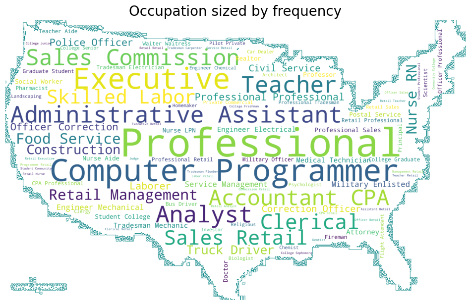

```python
#Reading in map
map_usa = np.array(Image.open('usa.jpg'))
#selecting the occupation columns and replace others with none with space separation
text = df_interest.loc[:, 'Occupation'].str.cat(others=None, sep=' ')

#wordcloud object
wc = WordCloud(background_color='white', max_words=200, mask=map_usa, stopwords=STOPWORDS,
        width=800, height=650, contour_width=0.01, contour_color='teal', scale=10)
wc.generate(text)
plt.figure(figsize = [12, 8])
plt.imshow(wc, interpolation='bilinear')
plt.title('Occupation sized by frequency', fontsize=20)
plt.axis('off');
```

#### Notes

> Most customers from prosper loan are Professional, Computer Programmer, Administrative Assitance, Executive, Teacher, Skilled Labor, Analyst, Retail Managment etc. This indicated that prosper loan either have a way to lure professional workers with might likely due to their interest rate as compared to the bank rates.

[figure not shown]

```python
import warnings
warnings.simplefilter(action='ignore')

list_dict = {0 : 'Not Available', 1 : 'Debt Consolidation', 2 : 'Home Improvement', 3: 'Business',
             4 : 'Personal Loan', 5 : 'Student Use', 6 : 'Auto', 7 : 'Other', 8 : 'Baby&Adoption',
             9 : 'Boat', 10 : 'Cosmetic Procedure', 11 : 'Engagement Ring', 12 : 'Green Loans',
             13 : 'Household Expenses', 14 : 'Large Purchases', 15 : 'Medical/Dental', 16 : 'Motorcycle',
             17 : 'RV', 18 : 'Taxes', 19 : 'Vacation', 20 : 'Wedding Loans'}

df_interest['ListingCategory'] = df_interest['ListingCategory (numeric)'].map(list_dict)

#checking the loan
categ_order = df_interest['ListingCategory'].value_counts().index
listing_counts = df_interest['ListingCategory'].value_counts()
sns.countplot(data = df_interest, y = 'ListingCategory', order=categ_order, color='green')
plt.ylabel('Listing Category')
plt.title('Listing Categories Distribution');
```

#### Notes

> Debt consolidation has the highest of all listing category of customers at Prosper loan.  
> Home improvement and Businesses are not the major listing of Prosper loan.

```python
df_interest
```

[output not shown]

[figure not shown]

```python
df_interest['LoanOriginalAmount']
sns.histplot(data=df_interest, x='LoanOriginalAmount', bins=20, kde=True, color='green')
plt.xlabel('Loan Amount ($)')
plt.ylabel('Count')
plt.title('Loan Original Amount $')
plt.show()
```

#### Notes

[figure not shown]

```python
# Term of Payment
sns.countplot(data=df_interest, x='Term', color='darkgreen')
plt.xlabel('Months')
plt.title('Term of Payment');
```

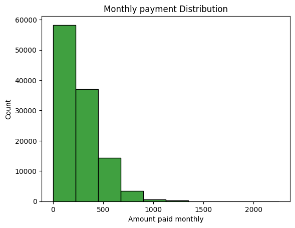

```python
df.MonthlyLoanPayment
sns.histplot(data=df, x='MonthlyLoanPayment', color='green', bins=10)
plt.xlabel('Amount paid monthly')
plt.ylabel('Count')
plt.title('Monthly payment Distribution')
plt.show();
```

#### Notes

> The amount paid back to Prsoper loan is $250. This better justify the lengnthly term needed to pay back the loan

[figure not shown]

```python
# define a classification function
def classify(row):
    if row["StatedMonthlyIncome"]<2500:
        return 'Low'
    if row["StatedMonthlyIncome"]<8000:
        return 'Medium'
    else:
        return 'High'

df_interest['WageGroup'] = df_interest.apply(classify, axis=1)

# convert string to ordinal category type and order them
ordinal_class = ['Low', 'Medium', 'High']
ordered_variable = pd.api.types.CategoricalDtype(ordered = True, categories = ordinal_class)
df_interest['WageGroup'] = df_interest['WageGroup'].astype(ordered_variable)

# Plot the new variable
sns.countplot(data = df_interest, x = 'WageGroup', color='lightgreen')
plt.title('Wage Group of Montly Income');
```

#### Notes

> Majority of customer from Prosper loan who have taken out credit are in the middle class and have an average monthly salary ranging from 2500 to 8000 dollars.

```python
df_interest['WageGroup']
```

[output not shown]

# Bivariate Exploration

> In this section, I investigated the relationships between pairs of variables in my data.

```python
# Numerical features
numeric_vars = [ 'CurrentCreditLines', 'OpenRevolvingAccounts',
               'DebtToIncomeRatio', 'LoanOriginalAmount', 'StatedMonthlyIncome', 'BorrowerAPR','BorrowerRate']
```

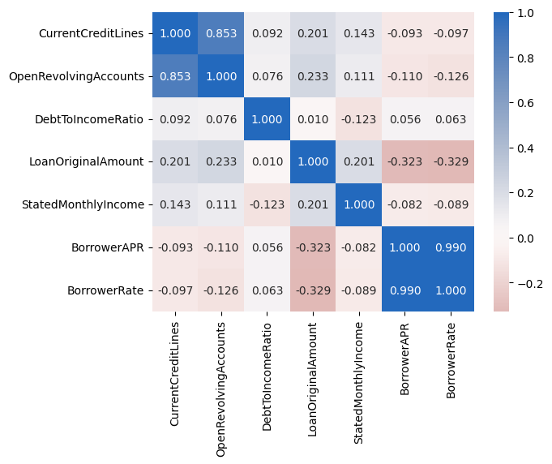

```python
# correlation plot
sns.heatmap(df_interest[numeric_vars].corr(), annot = True, fmt = '.3f',
           cmap = 'vlag_r', center=0)
plt.show()
```

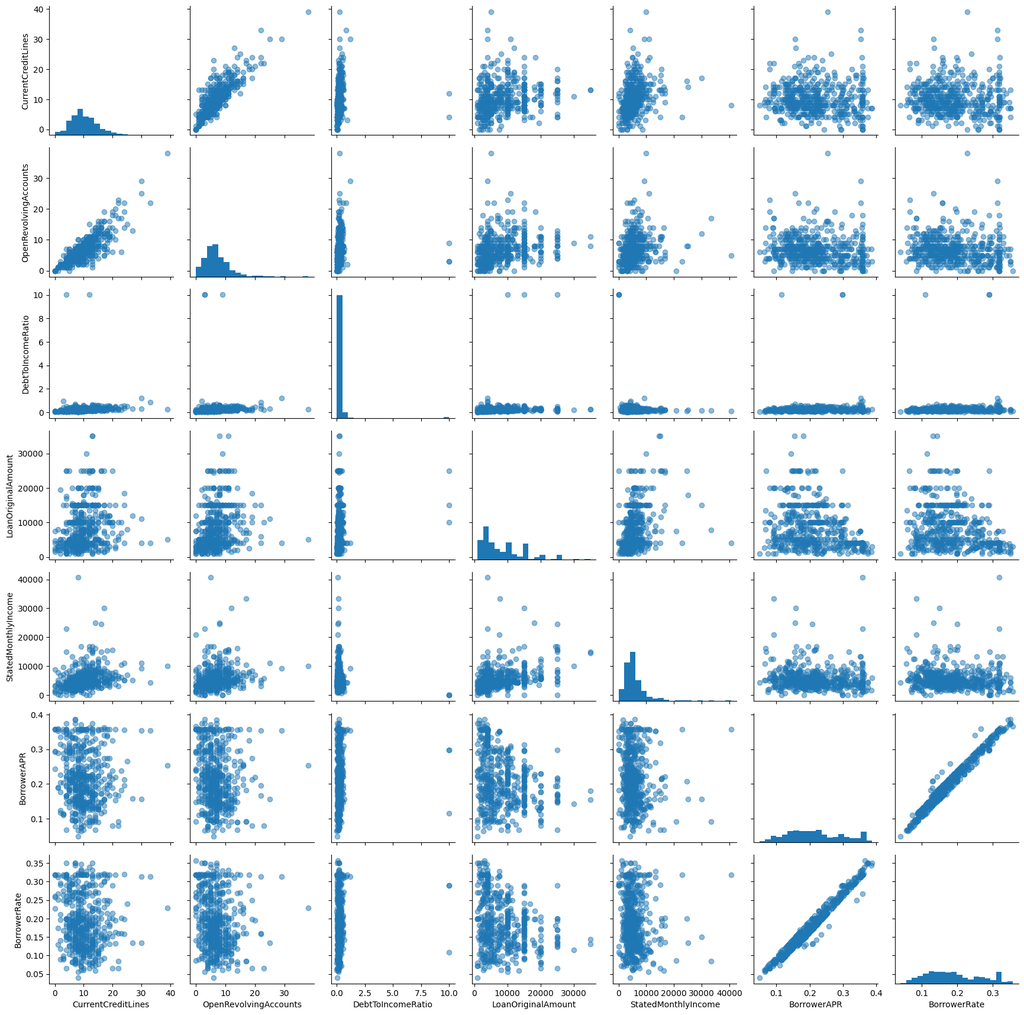

```python
# plot matrix: sample 500 loans so that plots are clearer
samples = np.random.choice(df_interest.shape[0], 500, replace = False)
df_samp = df_interest.reindex(samples)

# pair grid
g = sns.PairGrid(data = df_samp, vars = numeric_vars)
g = g.map_diag(plt.hist, bins = 20)
g.map_offdiag(plt.scatter, alpha = 1/2);
```

#### Notes

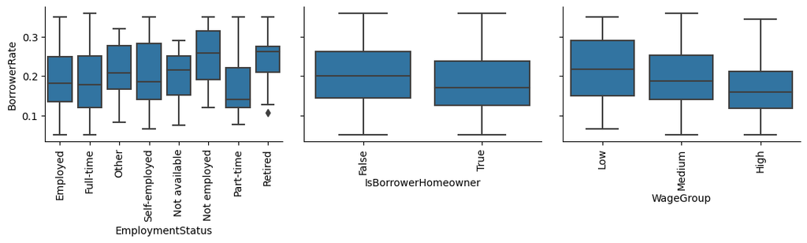

```python
# plot matrix of numeric features against categorical/ordinal features.
# use a 2000 sample since there are fewer plots and they're simpler in nature.
df_sample = df_interest.sample(2000, replace=False)

#define boxgrid function
def boxgrid(x, y, **kwargs):
    default_color = sns.color_palette()[0]
    sns.boxplot(x=x, y=y, color = default_color)
    plt.xticks(rotation=90);


g = sns.PairGrid(data = df_sample, y_vars = ['BorrowerRate'], x_vars = ['EmploymentStatus','IsBorrowerHomeowner','WageGroup'],
                aspect = 1.5);
g.map(boxgrid);
```

#### Notes

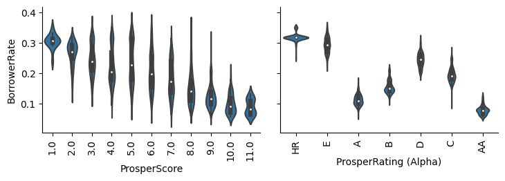

```python
#define violin function
def violin(x, y, **kwargs):
    default_color = sns.color_palette()[0]
    sns.violinplot(x=x, y=y, color = default_color)
    plt.xticks(rotation=90);

g = sns.PairGrid(data = df_sample, y_vars = ['BorrowerRate'], x_vars = ['ProsperScore','ProsperRating (Alpha)'],
                aspect = 1.5);
g.map(violin);
```

#### Notes

> The results shows The influence of ProsperScore and rating on BorrowerRate. It can be easily explained that the lower the PrspoerScore , the higher the BorrowerRates and vice versa. Prosper score of 1.0 would have a BorrowerRate of about 20-40% as compared to a better Score of 11 with about 2-15% r<borrowers ate. Same principle also applies to ProsperRating, A better rating of AA showed lower borrowers rate as compared to HR. And is the rating descends, the borrowers rate increases.

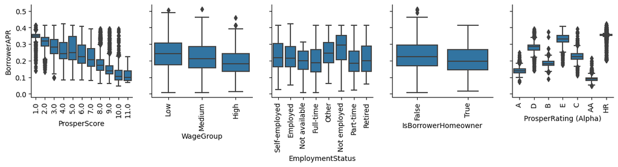

```python
#plot multiple figures with Pairgrid
g = sns.PairGrid(data = df_interest, y_vars = ['BorrowerAPR'],
                x_vars = ['ProsperScore','WageGroup','EmploymentStatus','IsBorrowerHomeowner', 'ProsperRating (Alpha)'])
g.map(boxgrid)
plt.show();
```

#### Notes

> The reults is also the same to the above conclude results when the only datasets is selected.

## Multivariate

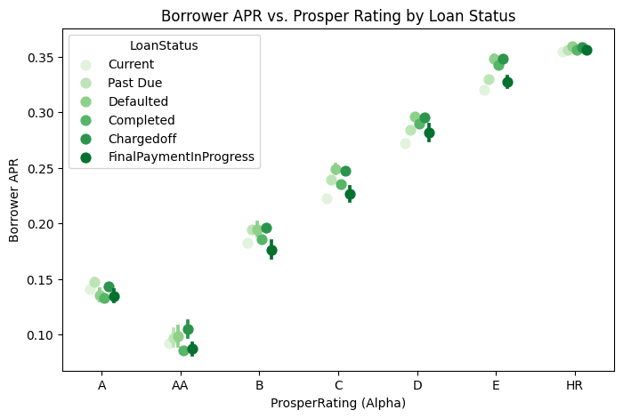

```python
fig = plt.figure(figsize=[8, 5])
ax = sns.pointplot(
    data=df_interest,
    x='ProsperRating (Alpha)',
    y='BorrowerAPR',
    hue='LoanStatus',
    palette='Greens',
    linestyles='',
    dodge=0.3,
    order=sorted(df_interest['ProsperRating (Alpha)'].unique())  # Order the categories in ascending order
)
plt.title('Borrower APR vs. Prosper Rating by Loan Status')
plt.ylabel('Borrower APR')
plt.show()
```

#### Note

> This plot shows the influence of Prosper rating and loan status on Borrower APR. Regardless of the loan status, prosper rating plays a better role on borrowers APR. The better the rating (AA to HR), the lesser the APR. For defaulted and charged off loans usually have a higher APR for all prosper rating except for AA and A.

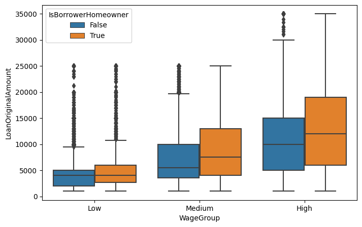

```python
#plot boxplot
plt.figure(figsize = [8,5])
sns.boxplot(data = df_interest, x = 'WageGroup', y = 'LoanOriginalAmount',hue = 'IsBorrowerHomeowner');
```

#### Notes

> Having a collateral and a higher wage help getting higher loan amount. It is clearly visible that being a home owner is a very important element to get a higher loan amount.

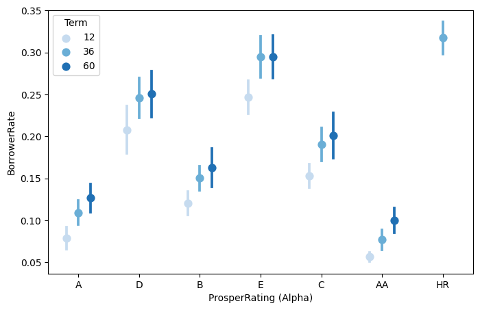

```python
#plot pointplot
fig = plt.figure(figsize = [8,5])
ax = sns.pointplot(data = df_interest, x = 'ProsperRating (Alpha)', y = 'BorrowerRate', hue = 'Term',
           palette = 'Blues', linestyles = '',dodge = 0.4, ci='sd')
```

#### Notes

> This results indicates the influence of Prosper rating, terms and borrower rates. Prosper rating is dependent on borrowes rate which is dependent on term. This means the better the rating and the shorter the term of payment, the lower the borrower rates. For better rating for example A, the interest is quite small when the term of payment is 12 months. However, as the term increases, the borrowers rate is also increases. All of this is true for all type of rating. HR only has a term payment of only 36 months as compared to all other rating.

# Conclusion

> The datasets was imported and column of interest was selected and assigned a data frame for better analysis. Univariate, Bivariate and Multivariate analysis was perfomed. The following was therefore summarised from the data sets
> - Most customers with a better prosper rating have a lower borrowers APR and borrowers rate.
> - Being a home owner (collateral) plays a major influence in the original loan amount. However, with a better wage group, the loan amount increases more.
> - In parallel, for all Prosper Ratings except for "A",and "AA", Defaulted and charged off loans usually have a higher Borrower APR compared to completed or current loans(good records).